# Objective 2: Depression Harmonization

Standalone analytical report

Published

May 25, 2026

## 1 Report Purpose

This standalone analytical report records the current Objective 2 depression-harmonization evidence used by the website deliverable page. It is not a manuscript. Its purpose is to keep the psychometric endpoint decision, thresholding logic, and portable scoring-engine status in one auditable place.

The report is anchored to the current psychometric website assets and the portable IRT engine catalogue. Unlike the shorter website page, this document keeps the instrument, threshold, and scoring-engine decisions visible together.

The current Objective 2 website page should continue to state that PHQ-9 remains the depression-oriented benchmark, SSQ-10 is the retained local depression-focused form, and the fixed-parameter SSQ-only engine is the preferred transport option for cohorts without PHQ items.

## 2 Source Files

|  | Source file | Modified |
| --- | --- | --- |
| website/_assets/obj03/factor_retention.png | website/_assets/obj03/factor_retention.png | 2026-05-04 10:13:00 SAST |
| website/_assets/obj03/ssq10_parallel_structure.png | website/_assets/obj03/ssq10_parallel_structure.png | 2026-05-04 10:13:00 SAST |
| website/_assets/obj03/loading_distributions.png | website/_assets/obj03/loading_distributions.png | 2026-05-04 10:13:00 SAST |
| website/_assets/obj03/harmonization_performance.png | website/_assets/obj03/harmonization_performance.png | 2026-05-04 10:13:00 SAST |
| website/_assets/obj03/table_threshold_performance.html | website/_assets/obj03/table_threshold_performance.html | 2026-05-04 10:13:00 SAST |
| portable_irt_engine/inst/engines/engine_catalog.csv | portable_irt_engine/inst/engines/engine_catalog.csv | 2026-05-25 08:44:08 SAST |

## 3 Analytical Question

CO-LUMINATE draws on studies that do not all use the same mental-health instrument. The analytical question is whether a defensible depression-oriented endpoint can be built across PHQ-9 and SSQ instruments without treating raw scores as interchangeable.

The working endpoint has three linked requirements:

- preserve the PHQ-9 as the depression-oriented benchmark;
- identify the SSQ form that best captures a depression-focused latent trait;
- provide a transportable scoring engine for cohorts where PHQ items are not available.

## 4 Instrument Set And Development Sample

The harmonization-ready development sample comprises 843 adolescents and young adults with concurrent baseline SSQ and PHQ measurement. The retained comparison set includes:

- PHQ-9 as the reference depression-oriented benchmark;
- the original SSQ-14;
- the theory-refined SSQ-10 depressive-content form;
- the shorter SSQ-08 subset.

## 5 Factor-Structure Evidence

The factor-retention and structure checks support the SSQ-10 as the retained local instrument for depression-focused harmonization. SSQ-14 remains broader and includes common-distress content that is not ideal for a transportable depression endpoint. SSQ-08 is shorter but removes too much of the stable depressive core.

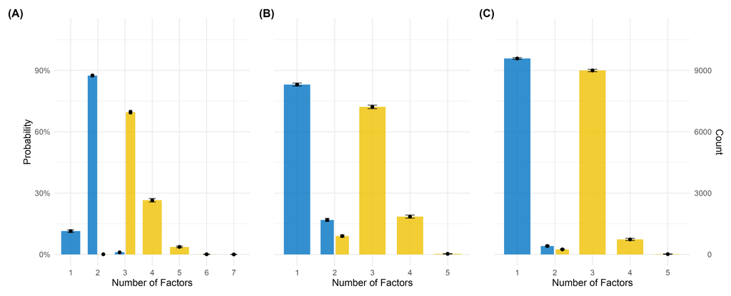

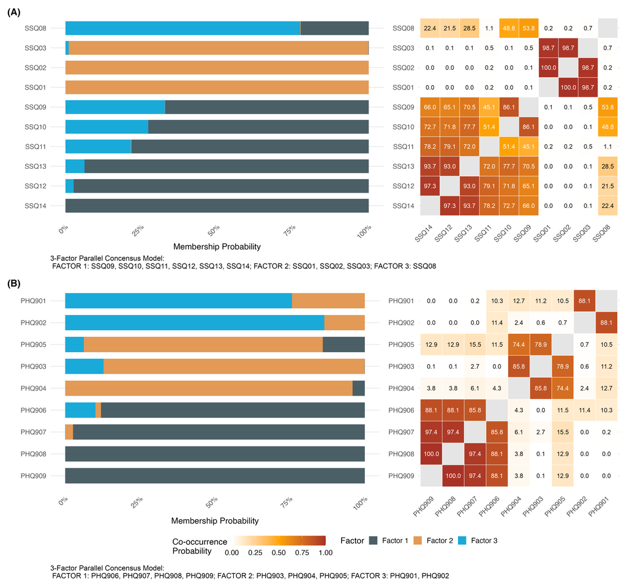

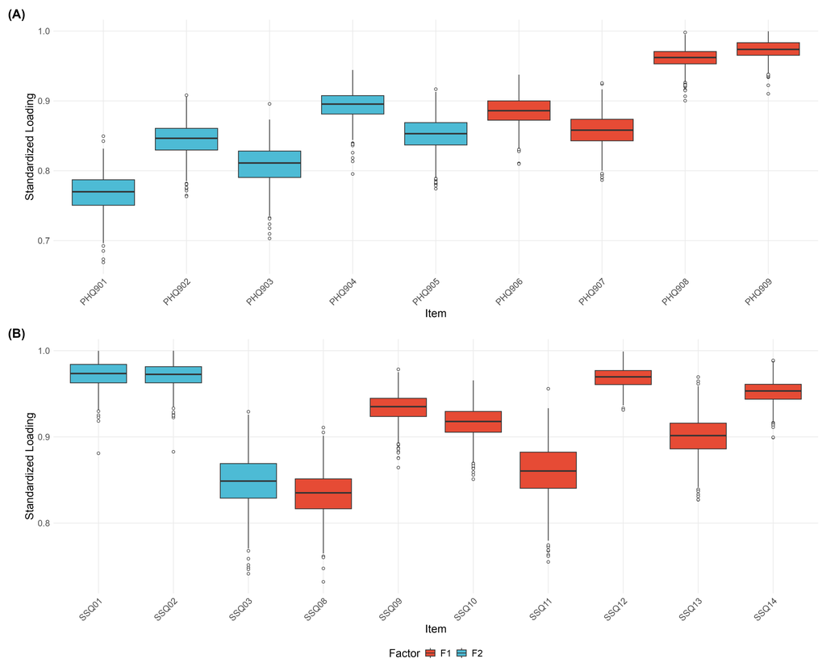

## 6 Thresholding Evidence

Threshold choice is central to Objective 2. A threshold can discriminate well while still producing an implausible burden estimate. The current decision therefore prioritizes calibration to the PHQ-9 benchmark and practical transport into SSQ-only cohorts.

| Strategy | Sensitivity | Specificity | PPV | Predicted prevalence | Operational readout |
| --- | --- | --- | --- | --- | --- |
| Naive ROC Youden on SSQ-10 sum score | 82.4% | 69.5% | 10.2% | 32.6% | High case capture, but severe prevalence inflation relative to the PHQ-9 benchmark. |
| PHQ-linked TCC anchor on the shared latent scale | 35.3% | 99.6% | 80.0% | 1.8% | Most conservative and most faithful to the PHQ-linked clinical standard. |
| Portable SSQ-only fixed-parameter scoring engine | 26.5% | 97.3% | 29.0% | 3.7% | Most practical transport option for SSQ-only cohorts while keeping prevalence close to the PHQ-9 reference. |

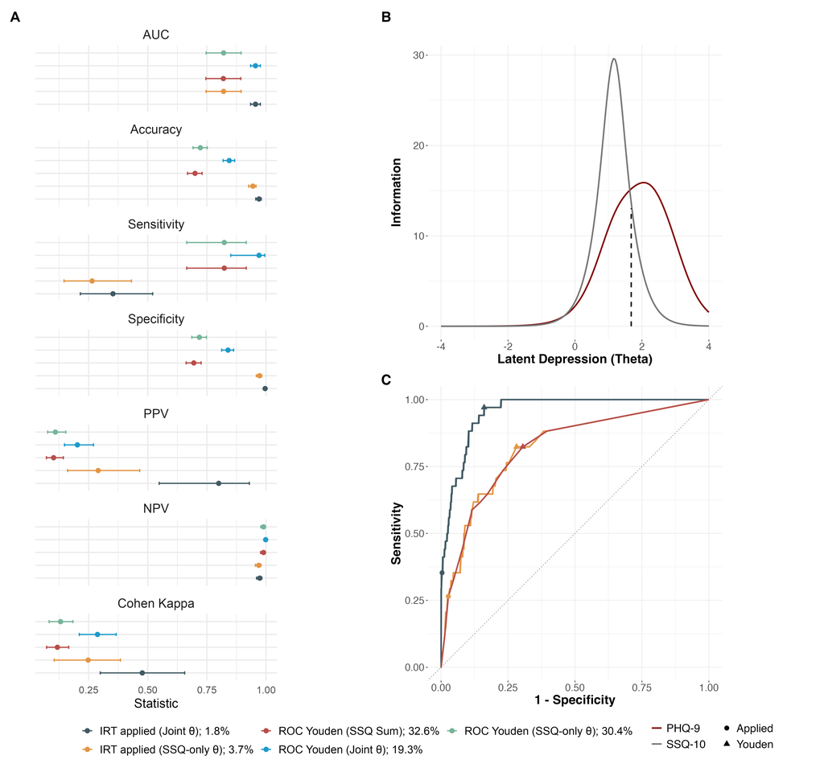

## 7 Portable Scoring Engine Status

The portable IRT engine catalogue currently contains 18 engine records. Of these, 13 are marked as available in the application and 13 are marked as scoring-ready.

| Engine label | Default | Factors | Cutoff method | Cutoff mode | Scoring ready |
| --- | --- | --- | --- | --- | --- |
| SSQ-10 Sens@Spec 1-Factor Overall | Yes | 1 | sens_at_spec | none | Yes |
| SSQ-10 Sens@Spec 1-Factor by Sex | No | 1 | sens_at_spec | SEX | Yes |
| SSQ-10 Sens@Spec 1-Factor by Age Group | No | 1 | sens_at_spec | AGEGRP | Yes |
| SSQ-10 Sens@Spec 1-Factor by Sex and Age Group | No | 1 | sens_at_spec | SEX_AGEGRP | Yes |
| SSQ-10 Spec@Sens 1-Factor Overall | No | 1 | spec_at_sens | none | Yes |
| SSQ-10 Spec@Sens 1-Factor by Sex | No | 1 | spec_at_sens | SEX | Yes |
| SSQ-10 Spec@Sens 1-Factor by Age Group | No | 1 | spec_at_sens | AGEGRP | Yes |
| SSQ-10 Spec@Sens 1-Factor by Sex and Age Group | No | 1 | spec_at_sens | SEX_AGEGRP | Yes |
| SSQ-10 Youden 1-Factor Overall | No | 1 | youden | none | Yes |
| SSQ-10 Youden 1-Factor by Sex | No | 1 | youden | SEX | Yes |
| SSQ-10 Youden 1-Factor by Age Group | No | 1 | youden | AGEGRP | Yes |
| SSQ-10 Youden 1-Factor by Sex and Age Group | No | 1 | youden | SEX_AGEGRP | Yes |
| SSQ-10 Model-TCC 1-Factor Overall | No | 1 | model_tcc | none | Yes |

The default production engine is SSQ-10 Sens@Spec 1-Factor Overall. This matches the public-facing recommendation: use the conservative fixed-parameter SSQ-10 transport engine when PHQ items are unavailable.

### 7.1 Complete Engine Catalogue

| Engine label | Available in app | Default | Factors | Cutoff method | Cutoff mode | Scoring ready |
| --- | --- | --- | --- | --- | --- | --- |
| SSQ-10 Sens@Spec 1-Factor Overall | Yes | Yes | 1 | sens_at_spec | none | Yes |
| SSQ-10 Sens@Spec 1-Factor by Sex | Yes | No | 1 | sens_at_spec | SEX | Yes |
| SSQ-10 Sens@Spec 1-Factor by Age Group | Yes | No | 1 | sens_at_spec | AGEGRP | Yes |
| SSQ-10 Sens@Spec 1-Factor by Sex and Age Group | Yes | No | 1 | sens_at_spec | SEX_AGEGRP | Yes |
| SSQ-10 Spec@Sens 1-Factor Overall | Yes | No | 1 | spec_at_sens | none | Yes |
| SSQ-10 Spec@Sens 1-Factor by Sex | Yes | No | 1 | spec_at_sens | SEX | Yes |
| SSQ-10 Spec@Sens 1-Factor by Age Group | Yes | No | 1 | spec_at_sens | AGEGRP | Yes |
| SSQ-10 Spec@Sens 1-Factor by Sex and Age Group | Yes | No | 1 | spec_at_sens | SEX_AGEGRP | Yes |
| SSQ-10 Youden 1-Factor Overall | Yes | No | 1 | youden | none | Yes |
| SSQ-10 Youden 1-Factor by Sex | Yes | No | 1 | youden | SEX | Yes |
| SSQ-10 Youden 1-Factor by Age Group | Yes | No | 1 | youden | AGEGRP | Yes |
| SSQ-10 Youden 1-Factor by Sex and Age Group | Yes | No | 1 | youden | SEX_AGEGRP | Yes |
| SSQ-10 Model-TCC 1-Factor Overall | Yes | No | 1 | model_tcc | none | Yes |
| SSQ-10 Sens@Spec 2-Factor Overall | No | No | 2 | sens_at_spec | none | No |
| SSQ-10 Sens@Spec 2-Factor by Sex | No | No | 2 | sens_at_spec | SEX | No |
| SSQ-10 Sens@Spec 2-Factor by Age Group | No | No | 2 | sens_at_spec | AGEGRP | No |
| SSQ-10 Sens@Spec 2-Factor by Sex and Age Group | No | No | 2 | sens_at_spec | SEX_AGEGRP | No |
| SSQ-10 Youden 4-Factor Overall | No | No | 4 | youden | none | No |

## 8 Evidence Figure Atlas

The figures below document the factor-retention, structure, loading, validity, and harmonization-performance evidence behind the shorter website page.

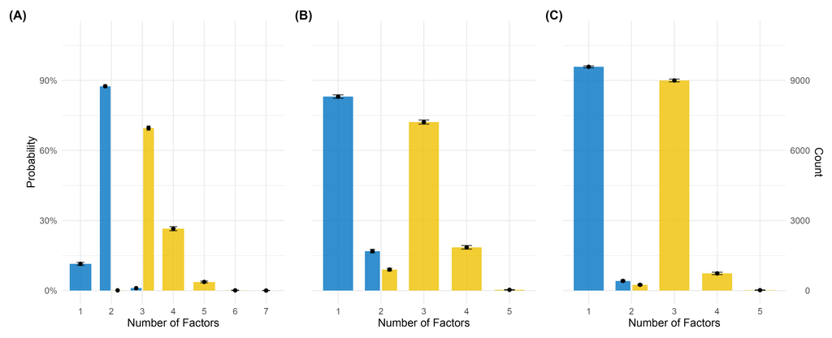

Factor Retention

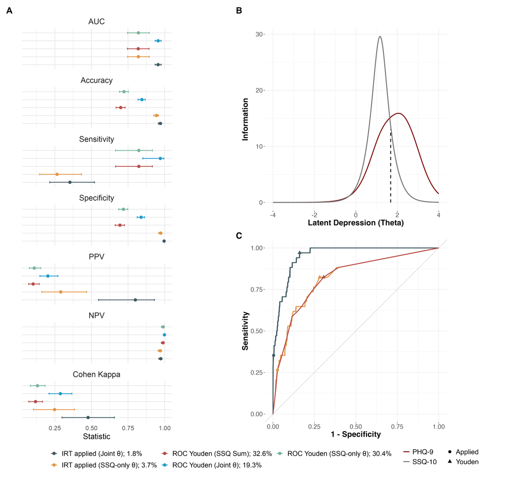

Harmonization Performance

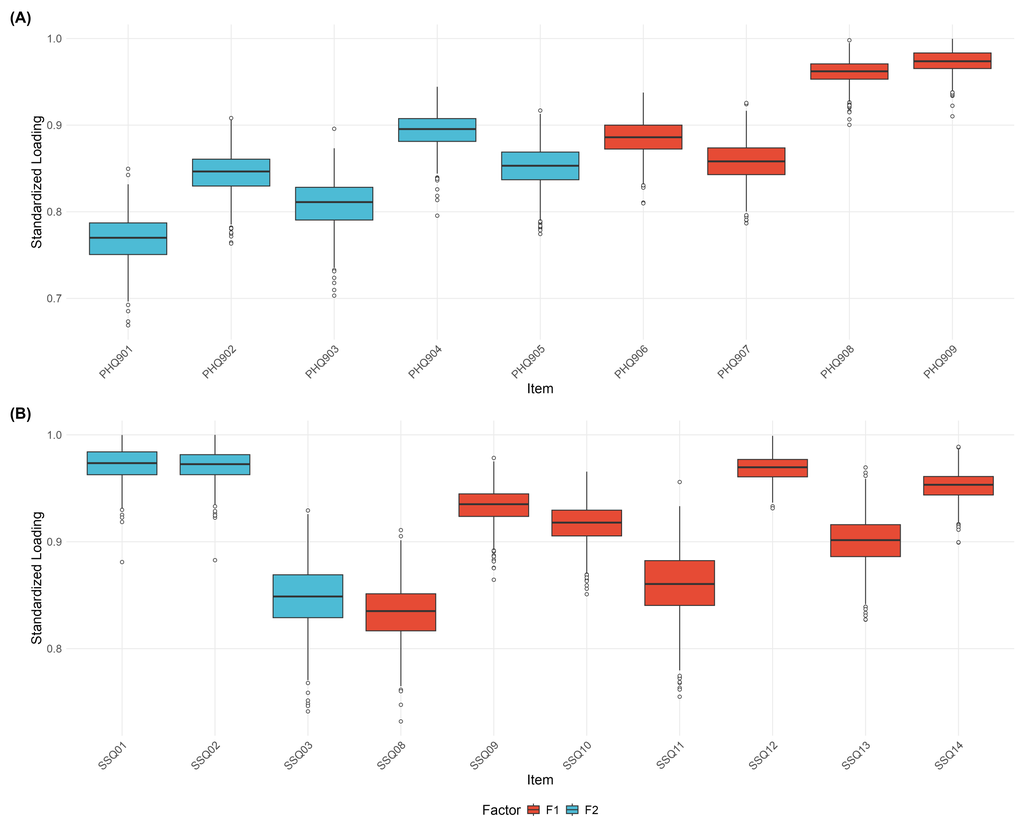

Loading Distributions

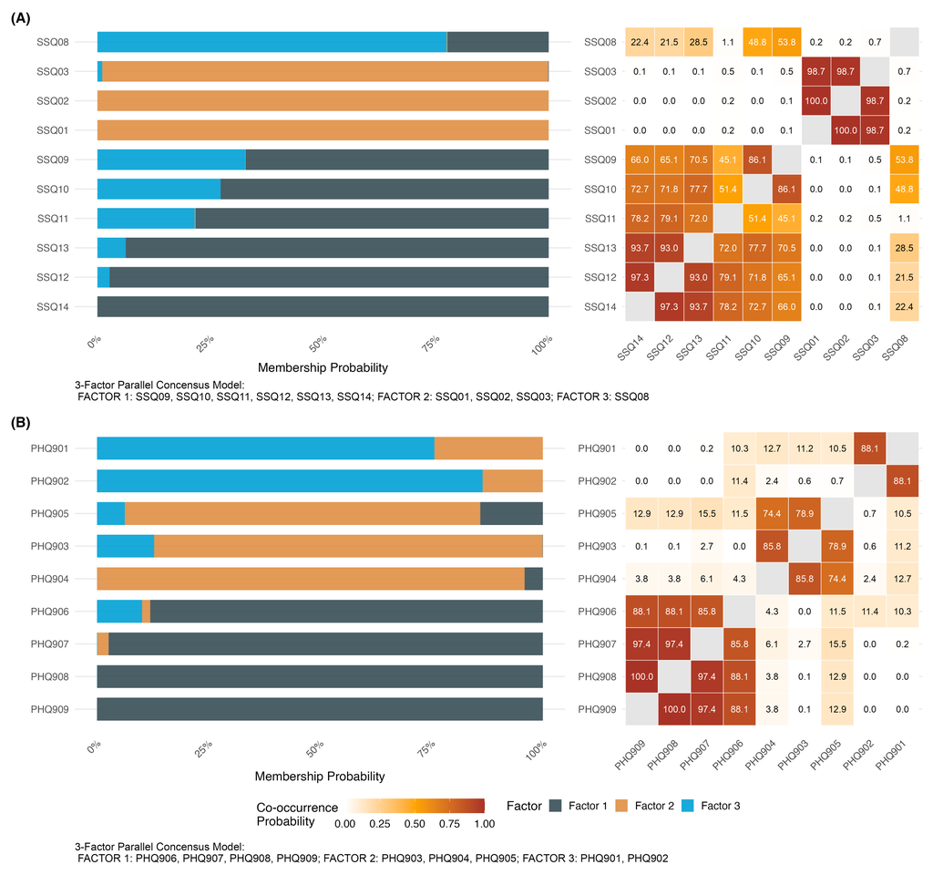

SSQ-10 Parallel Structure

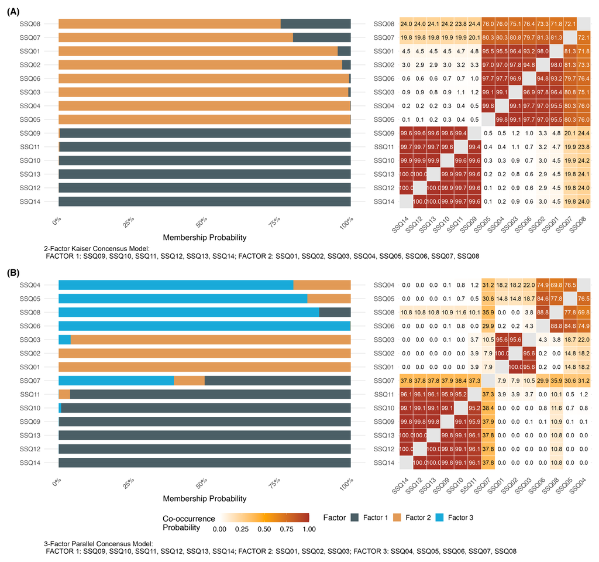

SSQ-14 Existing Structures Supplementary

## 9 Analytical Decision

The retained Objective 2 decision is:

- retain PHQ-9 as the depression-oriented benchmark;
- retain SSQ-10 as the local depression-focused form;
- avoid naive SSQ raw-score cutoffs as the primary endpoint definition;
- use the fixed-parameter SSQ-only IRT engine for transport into SSQ-only cohorts;
- report threshold interpretation conservatively, especially when prevalence estimates differ from the PHQ-linked benchmark.

## 10 Website Consistency Check

The Objective 2 website deliverable page is consistent with this analytical report if it includes:

- the PHQ-9 benchmark and SSQ-10 retained-form decision;
- the distinction between raw-score thresholding and IRT-calibrated thresholding;
- the portable SSQ-only engine as the practical transport route;
- the factor-retention, SSQ-10 structure, and harmonization-performance figures shown here.